# Statistical Models for Social Atlas Work-Injury Policy

## Regression Models

### Nate Breznau, primary contact breznau.nate@gmail.com

### Collaborative Research Institute ([SFB1342](https://www.socialpolicydynamics.de/en/)) “The Global Dynamics of Social Policy”

## Setup

Pacman used to install packages; however, check Colophon at end of this file for exact environment (R version, package versions).

```r
# necessary if not installed
# webshot::install_phantomjs()

knitr::opts_chunk$set(echo = TRUE, message=F, warning=F)

library(pacman)
pacman::p_load("tidyverse","ggplot2","kableExtra","GLMMadaptive",
               "countrycode","ragg", "sjPlot", "webshot",
               "sandwich")
```

## Data

```r
wi_df <- read.csv(here::here("data", "wi_df.csv"))
wi_df_comb <- read.csv(here::here("data","wi_df_comb.csv"))
```

## Models

Why 1923? Because the period after WWI was a major reconstruction in western Europe. Part of this ‘new Europe’ involved rapid adoption of welfare state and social security systems. This related to demobilization, new national socio-economic foci, and diffusion ([Obinger and Schmitt 2020](https://doi.org/10.1177/0958928719892852)).

#### First Dropping Non Adopters

One logic suggests that those who never adopted risk-pooling, should not be included in the analysis, as we cannot say reliably how long it takes for them to adopt.

```r
# without non-adopters

m01 <- lm(labor_workinjury_firstlaw_na ~ gdplog  + period1  +  period1*polity2i_first, data = wi_df)
m11 <- lm(scut ~ gdplog  + period1  + period1*polity2i_first, data = wi_df)
m21 <- lm(first2full_2 ~ gdplog  + period1  + period1*polity2i_first , data = wi_df)
m02 <- lm(labor_workinjury_firstlaw_na ~ gdplog  + period1  + period1*polity2i_first + commst + abol*noslave + noslave, data = wi_df)
m12 <- lm(scut ~ gdplog  + period1 + period1*polity2i_first + commst + abol*noslave + noslave, data = wi_df)
m22 <- lm(first2full_2 ~ gdplog  + period1 + period1*polity2i_first  +  commst + abol*noslave + noslave , data = wi_df)
tab_model(m01, m02, m11, m12, m21, m22, p.style = "stars", show.ci = F,
          rm.terms = c("(Intercept)","noslave"),
          dv.labels = c("First Law 1", "First Law 2", "First Full-Law 1", "First Full-Law 2", "Years Between 1", "Years Between 2"), pred.labels = c("GDP","pre-1923","Democracy, post-1923","Democracy, pre-1923","Communist","Abolition of\nEnslaved Labor","No Enslaved Labor"),
          p.threshold = c(0.10,0.05,0.01),
          file = here::here("results","tab1.html"))
```

First Law 1

First Law 2

First Full-Law 1

First Full-Law 2

Years Between 1

Years Between 2

Predictors

Estimates

Estimates

Estimates

Estimates

Estimates

Estimates

GDP

5.72 ***

7.43 ***

-0.69

0.01

-3.33 **

-4.30 ***

pre-1923

-45.82 ***

-43.30 ***

-36.44 ***

-35.45 ***

7.04 **

5.78 *

Democracy, post-1923

0.68 **

0.81 ***

-0.39

-0.17

-0.95 ***

-0.91 ***

Democracy, pre-1923

-1.08 **

-0.78 *

-0.69

-0.51

0.84 **

0.70 *

Communist

13.17 ***

10.31 **

-4.80 *

Abolition of Enslaved Labor

0.05 *

0.12 ***

0.03

No Enslaved Labor

0.05

-0.05

-0.07 *

Observations

173

173

173

173

173

173

R<sup>2</sup> / R<sup>2</sup> adjusted

0.582 / 0.572

0.666 / 0.649

0.405 / 0.391

0.463 / 0.437

0.145 / 0.125

0.188 / 0.148

- p<0.1 ** p<0.05 *** p<0.01

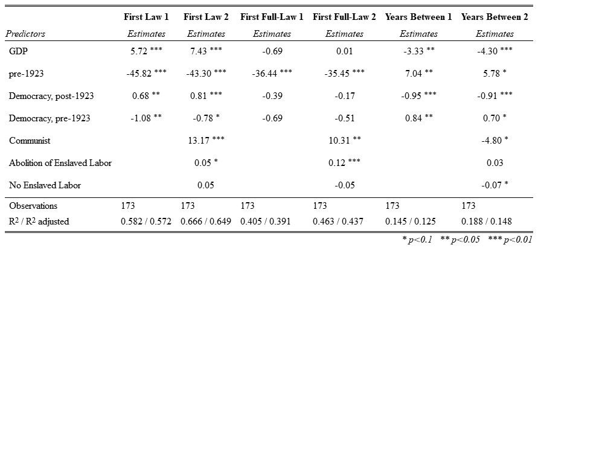

```r
webshot("results/tab1.html", "results/tab1.png", cliprect = "viewport")
```

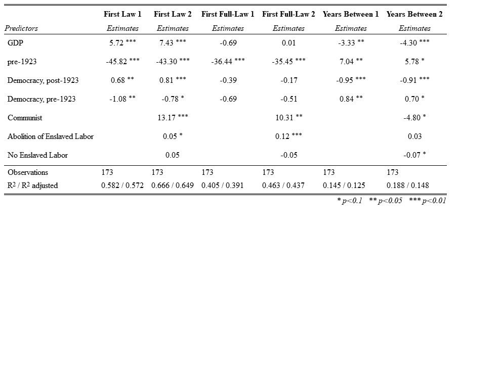

```r
knitr::include_graphics("results/tab1.png")
```

#### Including Non-Adopters

We treat non-adopters as having a 65 year lag between laws. This means they took very long to ‘adopt’, even though they have not yet adopted

```r
m04 <- lm(labor_workinjury_firstlaw ~ gdplog  + period1  +  period1*polity2i_first, data = wi_df)
m14 <- lm(scut_na ~ gdplog  + period1  + period1*polity2i_first, data = wi_df)
m24 <- lm(first2full_na_2 ~ gdplog  + period1  + period1*polity2i_first , data = wi_df)
m05 <- lm(labor_workinjury_firstlaw ~ gdplog  + period1  + period1*polity2i_first + commst + abol*noslave + noslave, data = wi_df)
m15 <- lm(scut_na ~ gdplog  + period1 + period1*polity2i_first + commst + abol*noslave + noslave, data = wi_df)
m25 <- lm(first2full_na_2 ~ gdplog  + period1 + period1*polity2i_first  +  commst + abol*noslave + noslave , data = wi_df)
tab_model(m04, m05, m14, m15, m24, m25, p.style = "stars", show.ci = F,
          rm.terms = c("(Intercept)","noslave"),
          dv.labels = c("First Law 1", "First Law 2", "First Full-Law 1", "First Full-Law 2", "Years Between 1", "Years Between 2"), pred.labels = c("GDP","pre-1923","Democracy, post-1923","Democracy, pre-1923","Communist","Abolition of\nEnslaved Labor","No Enslaved Labor"),
          p.threshold = c(0.10,0.05,0.01),
          file = here::here("results","tab2.html"))
```

First Law 1

First Law 2

First Full-Law 1

First Full-Law 2

Years Between 1

Years Between 2

Predictors

Estimates

Estimates

Estimates

Estimates

Estimates

Estimates

GDP

6.97 ***

8.72 ***

1.50

3.07

-0.70

-1.08

pre-1923

-46.50 ***

-44.04 ***

-35.98 ***

-33.84 ***

6.37 *

5.92

Democracy, post-1923

0.56 *

0.69 **

-0.77 *

-0.61

-1.35 ***

-1.34 ***

Democracy, pre-1923

-1.03 **

-0.75 *

-0.02

0.19

1.31 ***

1.22 ***

Communist

13.13 ***

10.97 **

-3.51

Abolition of Enslaved Labor

0.06 *

0.08 *

0.01

No Enslaved Labor

0.05

-0.00

-0.04

Observations

186

186

186

186

186

186

R<sup>2</sup> / R<sup>2</sup> adjusted

0.590 / 0.581

0.670 / 0.655

0.383 / 0.369

0.427 / 0.401

0.122 / 0.102

0.134 / 0.095

- p<0.1 ** p<0.05 *** p<0.01

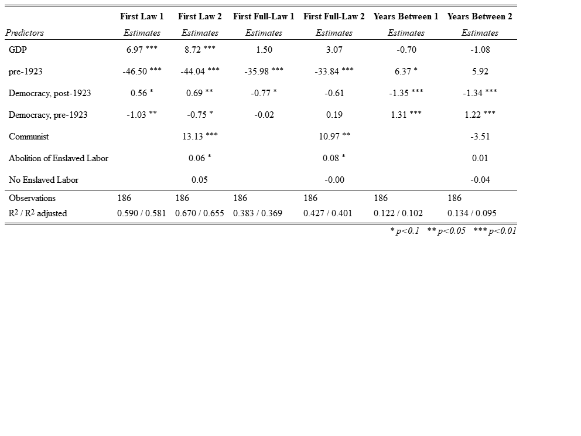

```r
webshot("results/tab2.html", "results/tab2.png", cliprect = "viewport")
```

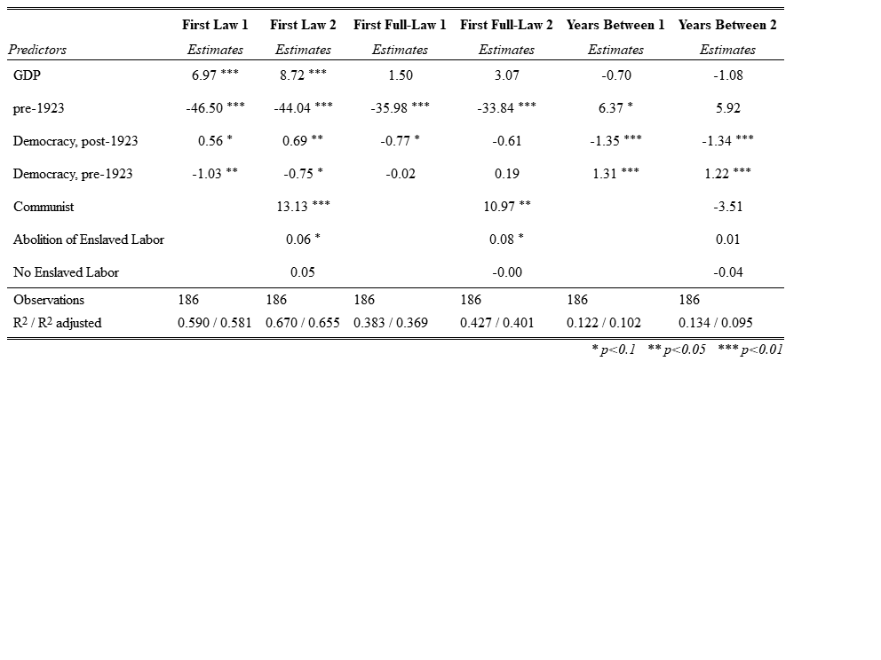

```r
knitr::include_graphics("results/tab2.png")
```

#### Third Treat Comm/Slave Cases Independently

```r
wi_df_comb <- wi_df_comb %>%
  subset(!is.na(wi_df_comb$scut))
m07 <- lm(labor_workinjury_firstlaw ~ gdplog  + period1  +  period1*polity2i_first, data = wi_df_comb, subset = !is.na(wi_df_comb$scut))
m17 <- lm(scut ~ gdplog  + period1  + period1*polity2i_first, data = wi_df_comb)
m27 <- lm(first2full ~ gdplog  + period1  + period1*polity2i_first , data = wi_df_comb)
m08 <- lm(labor_workinjury_firstlaw ~ gdplog  + period1  + period1*polity2i_first + commst + abol*noslave + noslave, data = wi_df_comb, subset = !is.na(wi_df_comb$scut))
m18 <- lm(scut ~ gdplog  + period1 + period1*polity2i_first + commst + abol*noslave + noslave, data = wi_df_comb)
m28 <- lm(first2full ~ gdplog  + period1 + period1*polity2i_first  +  commst + abol*noslave + noslave , data = wi_df_comb)
tab_model(m07, m08, m17, m18, m27, m28, p.style = "stars", show.ci = F,
          rm.terms = c("(Intercept)","noslave"),
          vcov.fun = "CL",
          vcov.type = "HC1",
          vcov.args = list(cluster = wi_df_comb$cow_code),
          dv.labels = c("First Law 1", "First Law 2", "First Full-Law 1", "First Full-Law 2", "Years Between 1", "Years Between 2"), pred.labels = c("GDP","pre-1923","Democracy, post-1923","Democracy, pre-1923","Communist","Abolition of\nEnslaved Labor","No Enslaved Labor Production"),
          p.threshold = c(0.10,0.05,0.01),
          file = here::here("results","tab3.html"))
```

First Law 1

First Law 2

First Full-Law 1

First Full-Law 2

Years Between 1

Years Between 2

Predictors

Estimates

Estimates

Estimates

Estimates

Estimates

Estimates

GDP

6.06 ***

7.78 ***

-0.77

-0.08

-4.40 ***

-5.19 ***

pre-1923

-46.65 ***

-43.82 ***

-36.73 ***

-35.52 ***

7.76 ***

6.23 **

Democracy, post-1923

0.70 *

0.83 **

-0.39

-0.16

-1.00 ***

-0.94 ***

Democracy, pre-1923

-1.13 ***

-0.78 *

-0.74

-0.53

0.80 **

0.69 **

Communist

14.88 ***

11.09 **

-2.65

Abolition of Enslaved Labor

0.06 **

0.13 ***

0.04

No Enslaved Labor Production

0.05

-0.06

-0.09 **

Observations

183

183

183

183

183

183

R<sup>2</sup> / R<sup>2</sup> adjusted

0.583 / 0.573

0.663 / 0.648

0.410 / 0.397

0.465 / 0.440

0.193 / 0.175

0.225 / 0.190

- p<0.1 ** p<0.05 *** p<0.01

[figure not shown]

```r
webshot("results/tab3.html", "results/tab3.png", cliprect = "viewport")
```

[figure not shown]

```r
knitr::include_graphics("results/tab3.png")
```

## AME

Calculate average marginal effects. This means calculating margins using predicted values with all covariates at their real values rather than their means. This gives a most accurate picture of the role of a given variable, given covariates. So not ‘all else equal’ but with an accurate ‘picture of reality’.

```r
# calculate average marginal effects by hand
wi_abol1840 <- subset(wi_df, noslave==0)
wi_abol1840$abol <- 1840
wi_abol1920 <- subset(wi_df, noslave==0)
wi_abol1920$abol <- 1920
wi_com0 <- wi_df
wi_com0 <- wi_com0 %>%
  mutate(
    #noslave = ifelse(commst == 1 & noslave == 0, 1, noslave),
         commst = 0)
wi_com1 <- wi_df
wi_com1 <- wi_com1 %>%
  mutate(
    #noslave = ifelse(commst == 1 & noslave == 0, 1, noslave),
         commst = 1)
wi_gdp2 <- wi_df
wi_gdp2$gdplog <- 2
wi_gdp3 <- wi_df
wi_gdp3$gdplog <- 3
wi_dem0 <- wi_df
wi_dem0$polity2i_first <- 0
wi_dem4 <- wi_df
wi_dem4$polity2i_first <- 4
p1 <- predict.lm(m22, newdata = wi_com0)
p2 <- predict.lm(m22, newdata = wi_com1)
p3 <- predict.lm(m22, newdata = wi_abol1840)
p4 <- predict.lm(m22, newdata = wi_abol1920)
p5 <- predict.lm(m22, newdata = wi_gdp2)
p6 <- predict.lm(m22, newdata = wi_gdp3)
p7 <- predict.lm(m22, newdata = wi_dem0)
p8 <- predict.lm(m22, newdata = wi_dem4)
a <- t.test(p2,p1)
b <- t.test(p4,p3)
c <- t.test(p6,p5)
d <- t.test(p8,p7)
fmarg <- as.data.frame(1)
fmarg[1,1] <- as.character("Communist")
fmarg[1,2] <- a$estimate[1] - a$estimate[2]
fmarg[1,3] <- a$conf.int[1]
fmarg[1,4] <- a$conf.int[2]
fmarg[2,1] <- as.character("Abolition of\nEnslaved Labor")
fmarg[2,2] <- b$estimate[1] - b$estimate[2]
fmarg[2,3] <- b$conf.int[1]
fmarg[2,4] <- b$conf.int[2]
fmarg[3,1] <- as.character("GDP per capita, log")
fmarg[3,2] <- c$estimate[1] - c$estimate[2]
fmarg[3,3] <- c$conf.int[1]
fmarg[3,4] <- c$conf.int[2]
fmarg[4,1] <- as.character("Democracy, PolityIV")
fmarg[4,2] <- d$estimate[1] - d$estimate[2]
fmarg[4,3] <- d$conf.int[1]
fmarg[4,4] <- d$conf.int[2]
fmarg[1,5] <- 4
fmarg[2,5] <- 3
fmarg[3,5] <- 2
fmarg[4,5] <- 1
```

### Fig 1. AMEs Old Version

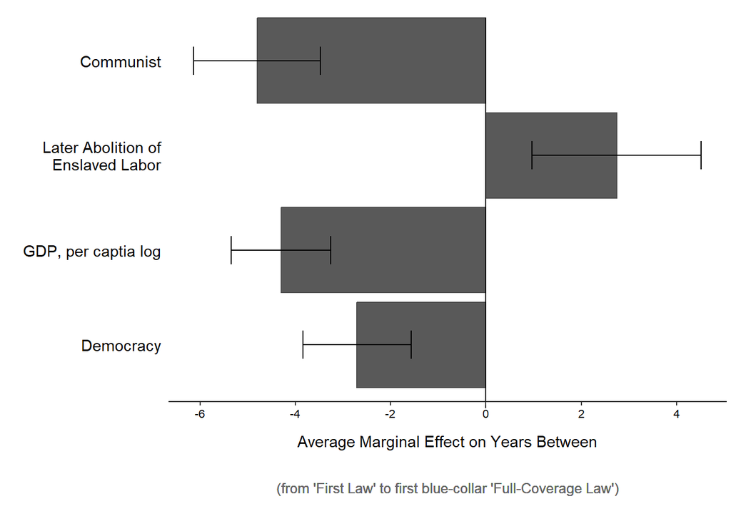

```r
p = ggplot(fmarg, aes(V5, V2)) + geom_col(color = "grey30") +
  geom_errorbar(aes(ymin = V3, ymax = V4), width = 0.3) +
  coord_flip(clip = "off") +
  scale_x_discrete(limits = c("Democracy", "GDP, per capita log", "Later Abolition of\nEnslaved Labor", "Communist"),
                   labels = c("Democracy", "GDP, per captia log", "Later Abolition of\nEnslaved Labor", "Communist")) +
  labs(x=c(""), y=c("Average Marginal Effect on Years Between"), color="black") +
  geom_text(label = " \n(from \'First Law\' to first blue-collar \'Full-Coverage Law\')",x = -0.4,y=-0.8, size=3.4, color="grey40") +
    geom_segment(y=0, yend=0,x=0.33,xend=4.45,  color="black", linetype=1) +
  scale_y_continuous(breaks = seq(-8, 8, by = 2)) +
  theme(plot.margin = unit(c(0.1,0.1,2,0.1), "cm"),
        panel.grid.major = element_blank(),
        panel.grid.minor = element_blank(),
        panel.background = element_blank(),
        axis.line.x = element_line(color = "black"),
        axis.text.x = element_text(color = "black", size = 8),
        axis.text.y = element_text(color = "black", size = 11),
        axis.ticks.y = element_blank(),
        axis.title.x = element_text(vjust = -2.5))
ggsave("results/Fig3.png", plot=p, height=4, width=6, units="in", dpi=660)
p
```

### Fig 1. AMEs New

Generate color graph that has all bars positive, but distinguishes positive and negative by color.

```r
# generate positive values and fill indicator

fmarg_pos <- fmarg %>%
  mutate(fill = ifelse(V2 < 0, "Decrease", "Increase"),
         V2 = abs(V2),
         V3 = abs(V3),
         V4 = abs(V4))


p = ggplot(fmarg_pos, aes(V5, V2)) +
  geom_col(aes(fill = as.factor(fill))) +
  geom_errorbar(aes(ymin = V3, ymax = V4), width = 0.3) +
  coord_flip(clip = "off") +
  scale_x_discrete(limits = c("Democracy", "GDP, per capita log", "Later Abolition of\nEnslaved Labor", "Communist"),
                   labels = c("A country with a 1-point\nhigher Democracy score\n(PolityIV scale out of 10)...", "A country twice as rich\n(log GDP per capita)...", "A country that took one\nyear longer to abolish\nenslaved labor...", "A country with a successful\ncommunist government...")) +
  labs(x=c(""), y=c("...had this average difference in transition time"), fill = "Adoption Time", color="black") +
  scale_fill_manual(name = c(""), values = c("forestgreen", "orangered4")) +

  scale_y_continuous(breaks = seq(0, 8, by = 2)) +
  theme(plot.margin = unit(c(0.1,0.1,2,0.1), "cm"),
        legend.position = "bottom",
        panel.grid.major = element_blank(),
        panel.grid.minor = element_blank(),
        panel.background = element_blank(),
        axis.line.x = element_line(color = "black"),
        axis.text.x = element_text(color = "black", size = 8),
        axis.text.y = element_text(color = "black", size = 11),
        axis.ticks.y = element_blank(),
        axis.title.x = element_text(vjust = -2.5))
ggsave("results/Fig1_pos.svg", plot=p, height=4, width=6, units="in", dpi=660)

knitr::include_graphics(here::here("results", "Fig1_pos.svg"))
```

[figure not shown]

## Scatterplot

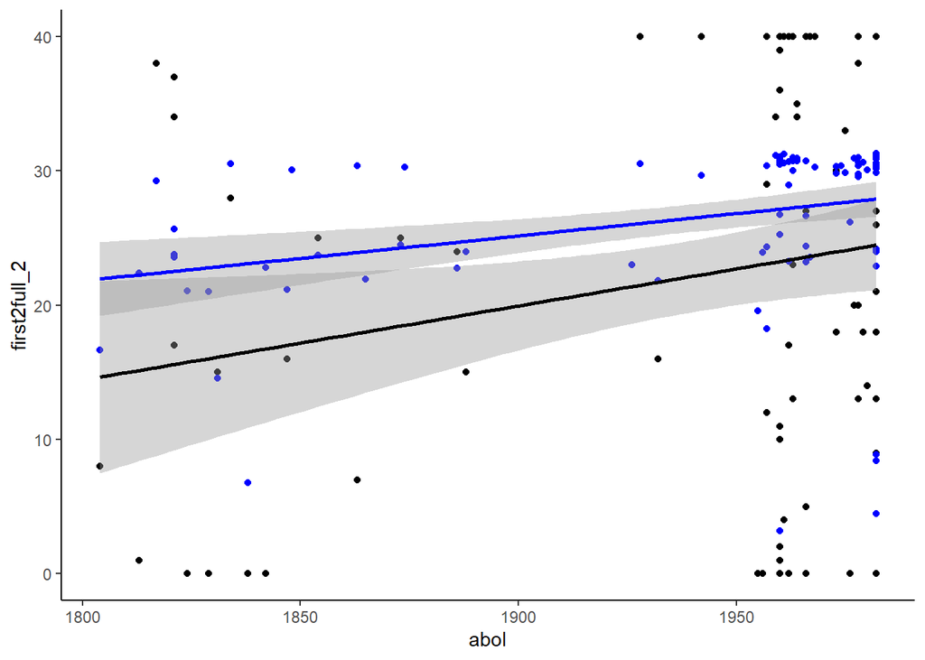

```r
# predict values
wi_df2 <- wi_df
wi_df2$f2f_i <- predict.lm(m24, newdata = wi_df2)
wi_df2 <- subset(wi_df2, noslave == 0)
# remove missing on Years Between
#wi_df2$f2f_i <- ifelse(is.na(wi_df2$first2full), NA, wi_df2$f2f_i)
# make residuals
wi_df2$f2f_r <- wi_df2$first2full_2 - wi_df2$f2f_i


wi_df2 %>%
ggplot() +
  geom_point(aes(x = abol, y = first2full_2)) +
  geom_point(aes(x = abol, y = f2f_i), color = "blue") +
  geom_smooth(aes(x = abol, y = first2full_2), method=lm, color="black", level = 0.90) +
  geom_smooth(aes(x = abol, y = f2f_i), method=lm, color="blue", level = 0.90) +
  #geom_point(aes(x = abol, y = first2full)) +
  #xlim(1950,2020) +
  theme_classic()
```

## References

Obinger, Herbert, and Carina Schmitt. 2020. “World War and Welfare Legislation in Western Countries.” Journal of European Social Policy 30(3):261–74. doi: 10.1177/0958928719892852.